# Quantitative Self Movement: Weight Lifting Exercise

#### Background

The following is taken from the Practical Machine Learning Course Project assignment and explains in detail the background information:

> Using devices such as Jawbone Up, Nike FuelBand, and Fitbit it is now possible to collect a large amount of data about personal activity relatively inexpensively. These type of devices are part of the quantified self movement - a group of enthusiasts who take measurements about themselves regularly to improve their health, to find patterns in their behavior, or because they are tech geeks. One thing that people regularly do is quantify how much of a particular activity they do, but they rarely quantify how well they do it. In this project, your goal will be to use data from accelerometers on the belt, forearm, arm, and dumbell of 6 participants. They were asked to perform barbell lifts correctly and incorrectly in 5 different ways. More information is available from the website here:http://groupware.les.inf.puc-rio.br/har (see the section on the Weight Lifting Exercise Dataset).

#### Exploratory Data Analysis

The training data for this project is downloaded from the following URL: https://d396qusza40orc.cloudfront.net/predmachlearn/pml-training.csv

The test data used to validate our findings is available at the following URL: https://d396qusza40orc.cloudfront.net/predmachlearn/pml-testing.csv

Before we explore the data we need to prepare our environment by loading the required R libraries and download the data from the above locations.

## Load Libraries

Load packages that are needed for the processing of the data, generation of the graphical figures and analysis of the data.

```r
library(RCurl)
library(caret)
library(rpart)
library(rpart.plot)
library(RColorBrewer)
library(rattle)
library(randomForest)
```

## Load Datasets

Read the Weight Lifting Exercises for both Training and Testing Data sets into memory. We can pre-tidy the data by setting empty elements to ‘NA’ during the loading of the data into memory.

```r
#define URLs
trainUrl <-"https://d396qusza40orc.cloudfront.net/predmachlearn/pml-training.csv"
testUrl <- "https://d396qusza40orc.cloudfront.net/predmachlearn/pml-testing.csv"

#Read Train Data
trainText <- getURL(trainUrl, ssl.verifypeer=0L, followlocation=1L)
trainData <- read.csv(text=trainText, na.strings=c("", "NA"))

#Read Test Data
testText <- getURL(testUrl, ssl.verifypeer=0L, followlocation=1L)
testData <- read.csv(text=testText, na.strings=c("", "NA"))
```

## Reviewing

The str command shows a nice detailed summary about the columns such as sample data, data types, and column names. Unfortunately this project restricts the length of the document, so I will only show the first few columns so you can get an idea of what the data looks like.

```r
str(trainData[1:8,1:20])
```

```
## 'data.frame':    8 obs. of  20 variables:
##  $ X                   : int  1 2 3 4 5 6 7 8
##  $ user_name           : Factor w/ 6 levels "adelmo","carlitos",..: 2 2 2 2 2 2 2 2
##  $ raw_timestamp_part_1: int  1323084231 1323084231 1323084231 1323084232 1323084232 1323084232 1323084232 1323084232
##  $ raw_timestamp_part_2: int  788290 808298 820366 120339 196328 304277 368296 440390
##  $ cvtd_timestamp      : Factor w/ 20 levels "02/12/2011 13:32",..: 9 9 9 9 9 9 9 9
##  $ new_window          : Factor w/ 2 levels "no","yes": 1 1 1 1 1 1 1 1
##  $ num_window          : int  11 11 11 12 12 12 12 12
##  $ roll_belt           : num  1.41 1.41 1.42 1.48 1.48 1.45 1.42 1.42
##  $ pitch_belt          : num  8.07 8.07 8.07 8.05 8.07 8.06 8.09 8.13
##  $ yaw_belt            : num  -94.4 -94.4 -94.4 -94.4 -94.4 -94.4 -94.4 -94.4
##  $ total_accel_belt    : int  3 3 3 3 3 3 3 3
##  $ kurtosis_roll_belt  : Factor w/ 396 levels "-0.016850","-0.021024",..: NA NA NA NA NA NA NA NA
##  $ kurtosis_picth_belt : Factor w/ 316 levels "-0.021887","-0.060755",..: NA NA NA NA NA NA NA NA
##  $ kurtosis_yaw_belt   : Factor w/ 1 level "#DIV/0!": NA NA NA NA NA NA NA NA
##  $ skewness_roll_belt  : Factor w/ 394 levels "-0.003095","-0.010002",..: NA NA NA NA NA NA NA NA
##  $ skewness_roll_belt.1: Factor w/ 337 levels "-0.005928","-0.005960",..: NA NA NA NA NA NA NA NA
##  $ skewness_yaw_belt   : Factor w/ 1 level "#DIV/0!": NA NA NA NA NA NA NA NA
##  $ max_roll_belt       : num  NA NA NA NA NA NA NA NA
##  $ max_picth_belt      : int  NA NA NA NA NA NA NA NA
##  $ max_yaw_belt        : Factor w/ 67 levels "-0.1","-0.2",..: NA NA NA NA NA NA NA NA
```

Of course summary will provide additional information about the data, but it’s too long to include in this report, but I list the command:

> summary(trainData)

In reviewing summary, we find several columns with 19,216 NA’s. This is just dirty data that will get in the way of training.

## Cleaning

I’m removing columns such as user_name, time stamps that would also impact the training models since they don’t provide any relevant information for the training models. During the load process, I pre-tidy the data by setting empty elements (field values) to ‘NA’. However, the data is littered with columns that will not provide relevant data to the training models. So we can clean those off next. Note that these are the columns with 19216 NA’s.

```r
# remove the columns that aren't needed for the training models
trainData <- subset(trainData, select= -c(X, user_name, raw_timestamp_part_1,
                                          raw_timestamp_part_2, cvtd_timestamp,
                                          new_window, num_window))
# Too many NA's to be of any use
trainData <- trainData[,colSums(is.na(trainData))<19216]
```

What we do to the Training data, we must also do to the testing data.

```r
# remove the columns that aren't needed for the training models
testData <- subset(testData, select= -c(X, user_name, raw_timestamp_part_1,
                                          raw_timestamp_part_2, cvtd_timestamp,
                                          new_window, num_window))
# Too many NA's to be of any use
testData <- testData[,colSums(is.na(testData))<19216]
```

#### Divide Data Training and Validation sets

Divide 60% of data to use for training and 40% of data for Validation

```r
inTrain = createDataPartition(y=trainData$classe, p=0.6, list=FALSE)
trainer = trainData[ inTrain,]
validator = trainData[-inTrain,]
```

#### Random Forest Model

Random Forest (rf), is one of the most used and accurate algorithms along with boosting.

```r
set.seed(1024)

rfTrControl <- trainControl( method = "repeatedcv",
                             number = 10,
                             repeats = 3,
                             preProcOptions = list(thresh = 0.9))

rfTuneGrid = expand.grid(mtry = c(2,4,8,15))

rfFit <- train(classe ~ ., data = trainer,
                method = "rf",
                preProcess="pca",
                trControl = rfTrControl,
                tuneGrid = rfTuneGrid)

rfFit
```

```
## Random Forest
##
## 11776 samples
##    52 predictor
##     5 classes: 'A', 'B', 'C', 'D', 'E'
##
## Pre-processing: principal component signal extraction (52), centered
##  (52), scaled (52)
## Resampling: Cross-Validated (10 fold, repeated 3 times)
## Summary of sample sizes: 10599, 10598, 10597, 10600, 10598, 10599, ...
## Resampling results across tuning parameters:
##
##   mtry  Accuracy   Kappa      Accuracy SD  Kappa SD
##    2    0.9624946  0.9525468  0.006199290  0.007842868
##    4    0.9611925  0.9508984  0.006825814  0.008633670
##    8    0.9580509  0.9469227  0.006530836  0.008261471
##   15    0.9499558  0.9366792  0.008650847  0.010935637
##
## Accuracy was used to select the optimal model using  the largest value.
## The final value used for the model was mtry = 2.
```

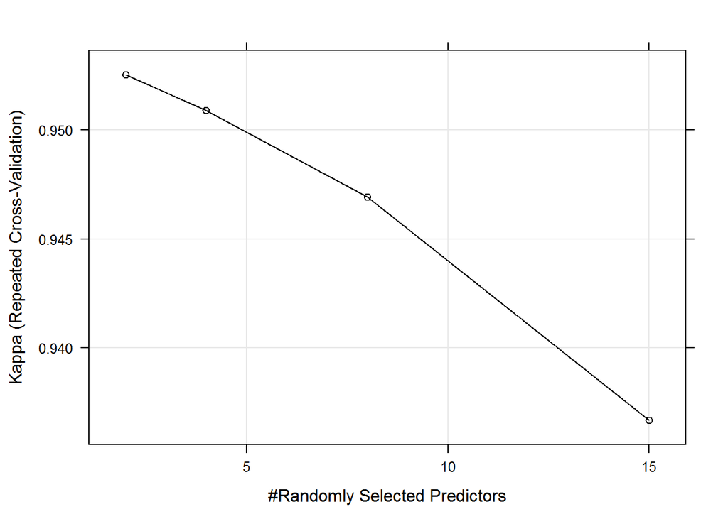

```r
trellis.par.set(caretTheme())
plot(rfFit, log="y", metric = "Kappa")
```

#### Bagging Model

Using Bagging Model as a comparison.

```r
set.seed(1024)

bagTrControl <- trainControl(method = "repeatedcv",
                             number = 10,
                             repeats = 3,
                             preProcOptions = list(thresh = 0.9))

bagFit <- train(classe ~ .,
                data = trainer,
                method = "bagFDA",
                B=10,
                preProcess="pca",
                trControl = bagTrControl)

bagFit
```

```
## Bagged Flexible Discriminant Analysis
##
## 11776 samples
##    52 predictor
##     5 classes: 'A', 'B', 'C', 'D', 'E'
##
## Pre-processing: principal component signal extraction (52), centered
##  (52), scaled (52)
## Resampling: Cross-Validated (10 fold, repeated 3 times)
## Summary of sample sizes: 10599, 10598, 10597, 10600, 10598, 10599, ...
## Resampling results across tuning parameters:
##
##   nprune  Accuracy   Kappa       Accuracy SD  Kappa SD
##    2      0.3309104  0.08629503  0.01291188   0.01939973
##    9      0.4775596  0.32651203  0.01363604   0.01695165
##   17      0.5401172  0.41372513  0.01354134   0.01736574
##
## Tuning parameter 'degree' was held constant at a value of 1
## Accuracy was used to select the optimal model using  the largest value.
## The final values used for the model were degree = 1 and nprune = 17.
```

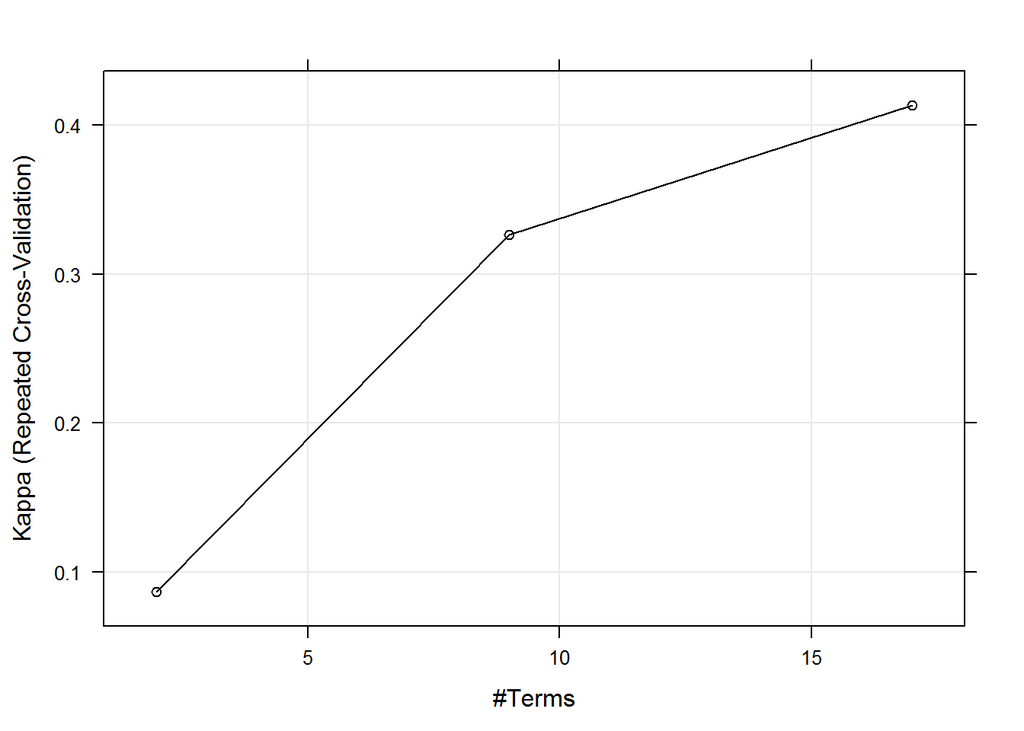

```r
trellis.par.set(caretTheme())
plot(bagFit, log="y", metric = "Kappa")
```

#### Validate Training

Comparing the training shows that Random Forests is much more accurate.

```r
results <- resamples(list(RF=rfFit, Bag=bagFit))
summary(results)
```

```
##
## Call:
## summary.resamples(object = results)
##
## Models: RF, Bag
## Number of resamples: 30
##
## Accuracy
##       Min. 1st Qu. Median   Mean 3rd Qu.   Max. NA's
## RF  0.9457  0.9599 0.9635 0.9625  0.9666 0.9737    0
## Bag 0.5140  0.5317 0.5404 0.5401  0.5482 0.5667    3
##
## Kappa
##       Min. 1st Qu. Median   Mean 3rd Qu.   Max. NA's
## RF  0.9313  0.9492 0.9539 0.9525  0.9578 0.9667    0
## Bag 0.3804  0.4026 0.4136 0.4137  0.4239 0.4476    3
```

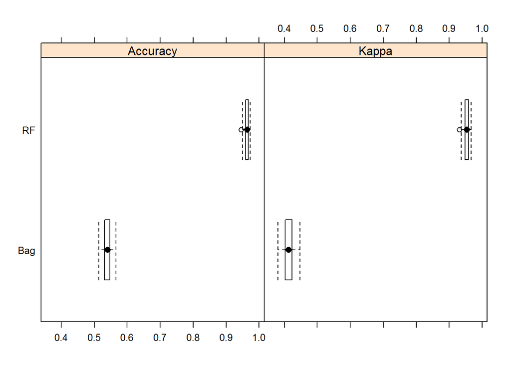

```r
bwplot(results)
```

Note that we are using some of the training data for data validation instead of using the test data. Since Random Forests is accurate, we’ll run the validation against it to find the out of sample error.

```r
# calculate outcome for validation data
validatePrediction <- predict(rfFit,validator)

# compare results
confusionMatrix(validator$classe, validatePrediction)
```

```
## Confusion Matrix and Statistics
##
##           Reference
## Prediction    A    B    C    D    E
##          A 2205   17    4    1    5
##          B   33 1450   30    5    0
##          C   10   18 1312   22    6
##          D   15    8   61 1198    4
##          E    1    6   13    7 1415
##
## Overall Statistics
##
##                Accuracy : 0.9661
##                  95% CI : (0.9619, 0.97)
##     No Information Rate : 0.2886
##     P-Value [Acc > NIR] : < 2.2e-16
##
##                   Kappa : 0.9571
##  Mcnemar's Test P-Value : 4.805e-08
##
## Statistics by Class:
##
##                      Class: A Class: B Class: C Class: D Class: E
## Sensitivity            0.9739   0.9673   0.9239   0.9716   0.9895
## Specificity            0.9952   0.9893   0.9913   0.9867   0.9958
## Pos Pred Value         0.9879   0.9552   0.9591   0.9316   0.9813
## Neg Pred Value         0.9895   0.9923   0.9833   0.9947   0.9977
## Prevalence             0.2886   0.1911   0.1810   0.1572   0.1823
## Detection Rate         0.2810   0.1848   0.1672   0.1527   0.1803
## Detection Prevalence   0.2845   0.1935   0.1744   0.1639   0.1838
## Balanced Accuracy      0.9846   0.9783   0.9576   0.9792   0.9927
```

Again, this shows that accuracy is very high with the Random Forest model.

Since we built the models, and they took such a long time to run, I’m saving them to files for use during the quiz portion of the project, including the tidy test data.

```r
# if they exist, then let's not override them

if (!file.exists("rfFit.RData"))
    save(rfFit, file = "rfFit.RData")

if (!file.exists("bagFit.RData"))
    save(bagFit, file = "bagFit.RData")

if (!file.exists("testing.RData"))
    save(testData, file = "testData.RData")

# to load the data use 'load(sourceFileName)'
```

#### Reasons for Choices Made

- Bagging and Random Forrest models were chosen due to their reputation for accurate results and because they fit well with the data model.
- Random Forest produced the best results, so it was chosen for perdition validation.
- TrainControl was used and parameters set based on on-line research (Google) and recommendations from a colleague at work. The re-sampling iterations was set to 10 as well as the number of sets to compute was set to 3 based on recommendations located at this site for repeated k-fold cross validation: http://machinelearningmastery.com/how-to-estimate-model-accuracy-in-r-using-the-caret-package/